# Approaches to biomedical knowledge

Session #2: Gene Ontology and Overrepresentation Analysis

Peter N Robinson

## Overview

- Gene Ontology (GO)
- GO Overrepresentation Analysis
- Gene-Set Enrichment Analysis
- GO Causal Activity Modeling

## Gene Ontology

The Gene Ontology (GO) is being developed with the goal of providing a set of structured vocabularies for the annotation of genes and their products. Since the publication of the original paper in *Nature Genetics* in 2000<sup>1</sup>, GO has become one of the most widely used and mature bio-ontologies, although it is still very much a work in progress.

[figure not shown]

[^1]: Ashburner M, et al (2000) Gene ontology: tool for the unification of biology. The Gene Ontology Consortium. Nat Genet. 25(1):25-9

## Why do we need GO?

- **Exponential increase in biological data** $\longmapsto$ need for databases with appropriate representation techniques.
- **Lag in functional description** $\longmapsto$ progress in how biologists describe functions has not kept pace with large-scale sequencing. Need for efficient procedures for preliminary annotation.
- **Divergent Nomenclature** $\longmapsto$ names for genes and functions vary widely between databases, making cross-species comparison difficult.
- **Primary Uses:**
  - Overrepresentation analysis/Pathway analysis of high-throughput data
  - Data mining from PubMed etc.
  - Database integration

## GO: A Structured Hierarchy

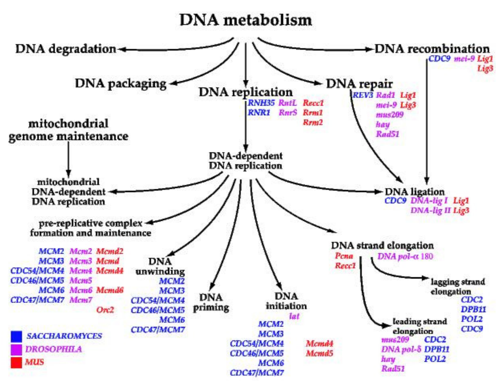

## DNA Ligation: GO:0006266

The following represents the lineage of the term **DNA ligase (ATP) activity** (GO:0003910):

[figure not shown]

## DAG: Directed Acyclic Graph

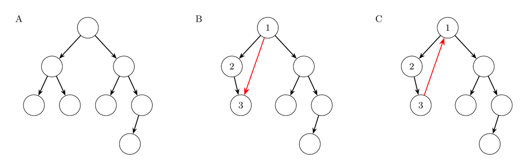

- Gene Ontology is a directed acyclic graph (DAG)
  1. Tree
  2. A graph with directed edges and no cycles
  3. A graph with a cycle

## QuickGO: DAG

[figure not shown]

Source: https://www.ebi.ac.uk/QuickGO/term/GO:0003678

## Tree

- Simpler data structure without multiple parentage
- e.g. EC: Enzyme commision definitions of enzyme classes, subclasses and sub-subclasses

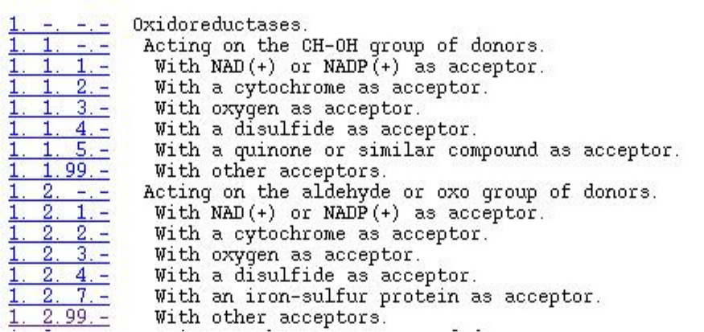

# Function?

The term function is sometimes used in a rather vague way..

- biochemical activity
- biological goals
- subcellular localization

[figure not shown]

## GO: Biological Process

- **Definition:** The biological objective to which the gene or gene product contributes.
- **Composition:** A process is accomplished by one or more assemblies of molecular functions.
- **Characteristics:** These processes often involve chemical or physical transformations.
- **Examples:**
  - **High Level:** “Signal Transduction”, “Cell Growth and Maintenance”
  - **Lower Level:** “Pyrimidine Metabolism”, “cAMP Biosynthesis”

figure credit: EMBL-EBI

## GO: Molecular Function

- **Definition:** The biochemical activity of a gene product (the specific “job”).
- **The “What”:** Describes **what** is done, rather than why, where, or when.
- **Examples:**
  - **High Level:** “Enzyme”, “Transporter”
  - **Lower Level:** “Adenylate Cyclase”, “Toll Receptor Ligand”

**GO Molecular function**

Molecular functions generally correspond to the individual steps in a biological process (like the activity of a single protein within a metabolic pathway).

figure credit: EMBL-EBI

## GO: Cellular Component

- **Definition:** The place in the cell where a gene product is active.
- **Specific Locations:**
  - Example: “Nuclear membrane”
- **Multi-protein Complexes:** Can also refer to stable entities made up of multiple gene products.
  - Examples: “Ribosome”, “Proteasome”

**Note**

A cellular component is not just a “where”—it can be a functional structure like a protein complex that acts as a unit.

figure credit: EMBL-EBI

## GO Terms: The Anatomy of an Entry

Each entry (*term*) in the Gene Ontology contains these standardized metadata fields to ensure consistency across different databases.

```
[Term]
id: GO:0003678
name: DNA helicase activity
namespace: molecular_function
alt_id: GO:0003679
alt_id: GO:0004003
def: "Unwinding of a DNA helix, driven by ATP hydrolysis." [GOC:jl]
synonym: "ATP-dependent DNA helicase activity" EXACT []
xref: EC:3.6.4.12
xref: Reactome:R-HSA-5693589 "D-loop dissociation and strand annealing"
is_a: GO:0004386 ! helicase activity
is_a: GO:0008094 ! ATP-dependent activity, acting on DNA
property_value: skos:exactMatch EC:3.6.4.12
```

## GO Annotations

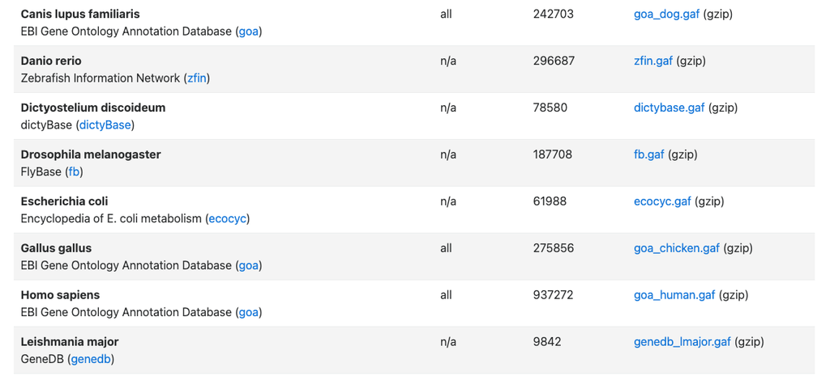

Source: https://current.geneontology.org/products/pages/downloads.html

## GO Annotations

- **Gene Association Files (GAFs):** Collaborating databases (like FlyBase, MGI, or UniProt) prepare and maintain these files.
- **Cardinality ($0$ to $n$):**
  - A gene product may have **zero** entries if its function is entirely unknown.
  - A single gene product often has **multiple entries** across the three domains (Cellular Component, Molecular Function, and Biological Process).
- **Granularity:** One protein can be localized to the nucleus *and* the cytoplasm, while acting as both a transcription factor *and* a dimerizing agent.

**The “Annotation” vs. “Term”**

Remember: A **Term** is a definition in the ontology. An **Annotation** is the link between a specific gene and that term.

## GO Annotations

- **Gene Association Files (GAFs):** Collaborating databases prepare and maintain these files to link genes to terms.
- **Cardinality ($0$ to $n$):**
  - A gene product may have **zero** entries if nothing is known about it.
  - One gene product often has **multiple entries** covering its Cellular Component, Molecular Function, and Biological Process.

## Example: Deoxyribonuclease II

An annotation record typically includes:

| Field | Value | Description |
| --- | --- | --- |
| **Accession** | `O00115` | Unique protein identifier |
| **DB Name** | `DRN2_HUMAN` | Standardized database symbol |
| **GO ID** | `GO:0003677` | The GO term assigned (DNA binding) |
| **Evidence** | `TAS` | **Traceable Author Statement** |

**Metadata**

Records also include synonyms, PubMed IDs, Taxon (species), and the date the annotation was last updated (biocuration date).

## GO Evidence Codes

How do we know that a gene product has a certain function?

### 1. Manually Curated (Experimental)

- **IDA:** Inferred from Direct Assay (“Gold Standard”)
- **IMP:** Inferred from Mutant Phenotype
- **IGI:** Inferred from Genetic Interaction

### 2. Manually Curated (Non-Experimental)

- **TAS:** Traceable Author Statement (Found in a peer-reviewed paper)
- **NAS:** Non-traceable Author Statement

### 3. Automated (Computational)

- **IEA:** Inferred from Electronic Annotation (The most common type)
- **ISO:** Inferred from Sequence Orthology

**Caution**

Many high-throughput analyses filter out **IEA** codes because they are automated and tend to have a higher false-positive rate as compared to experimental data.

## GO: Overrepresentation Analysis

**The Situation**

We have performed a high-throughput experiment (e.g., RNA-seq) and identified a list of differentially expressed genes. What are the **salient characteristics** of the genes in this list?

- **Beyond Counting:** We cannot simply count genes annotated to a term. Why? Because common biological processes are naturally common in the genome.
- **Core Question:** Is a specific GO term annotated to our gene list **more often than we would expect by random chance?**
- **Approach:** We use the **Fisher’s Exact Test** (standard procedure).
  - Today’s demonstration will use the **Ontologizer** software.

## The Binomial Coefficient

To calculate the number of unique ways to arrange $k$ “heads” and $n-k$ “tails,” we must account for redundant rearrangements:

- **Total Permutations:** There are $n!$ ways to rearrange $n$ distinct objects.
- **Redundancy Correction:** Exchanging the positions of two “heads” does not change the observable sequence.
  - There are $k!$ ways to reorder the “heads” without chainging the overall sequence.
  - Similarly, there are $(n-k)!$ ways to reorder the “tails” without changing the sequence.
- **The Formula:** To find the number of *distinct* orderings, we divide the total by the redundancies:

$$\binom{n}{k} = \dfrac{n!}{(n-k)! k!}
\tag{1}$$

**Note**

This value $\binom{n}{k}$, represents the number of different ways of choosing $k$ items from a set of $n$ items where the order of selection does not matter.

## Binomial Coefficient

- This quantity (read “$n$ choose $k$”) is known as the binomial coefficient. We can now use this to calculate the probability of obtaining $k$ *successes* in $n$ trials, whereby the probability of *success* in one trial is $p$, and the probability of *failure* is $q=1-p$.
- The probability of a particular order of trials with $k$ successes and $n-k$ failures is obtained by multiplying the probabilities of the individual trials;

$$p^k(1-p)^{n-k}$$

- The total probability of obtaining $k$ successes is the probability of one particular trial order with $k$ successes by the number of trial orders resulting in $k$ successes, which is given by the binomial coefficient. This probability distribution is called the **binomial distribution**:

$$P(k,n,p) = \binom{n}{k} p^k(1-p)^{n-k}
\tag{2}$$

# Binomial Coefficient

For instance, the figure shows

1. the probability of $k=1,\ldots,10$ “heads” in ten coin tosses using a fair coin ($p=0.5$).
2. Probability of $k=1,\ldots,10$ “heads” in ten coin tosses using a biased coin ($p=0.1$).

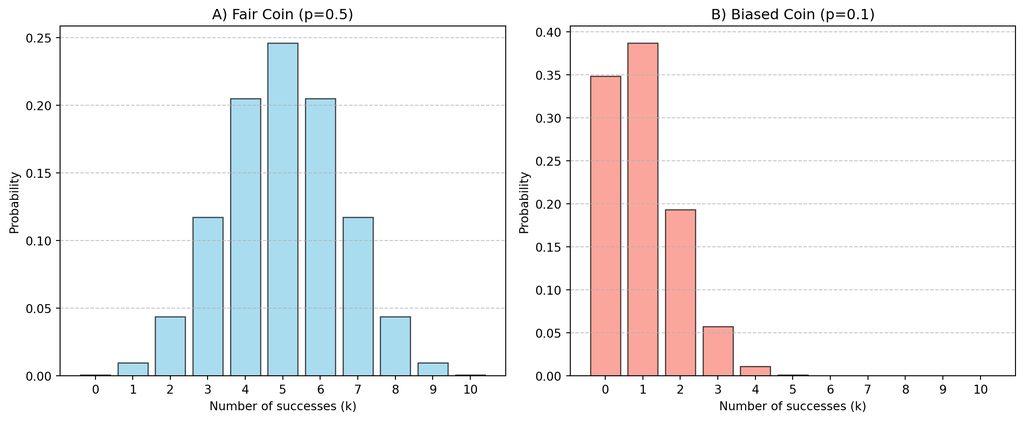

## GO Overrepresentation with the Binomial Distribution

GO overrepresentation analysis can be modeled as a binomial distribution in which each gene in the study set is considered to be a “trial,” and “success” occurs if the gene is annotated to a GO term of interest.<sup>1</sup>

- The probability of “success” is simply the frequency of the annotation to the GO term among all genes.
- For instance, if there are 10,000 genes on a microarray chip, 600 of which are annotated to some GO term $t$, then the probability of $t$ is $p=600/10,000=0.06$.
- If we perform an experiment using microarray hybridizations and identify 250 differentially expressed genes (the “DE set”), 30 of which are annotated to $t$, we can use the binomial distribution to find the probability of observing exactly 30 genes in the DE set annotated to $t$ as:

$$P(30, 250, 0.06) = \binom{250}{30} 0.06^{30} (1-0.06)^{250-30} = 1.44 \times 10^{-4}$$

[^2]: We will see shortly that the binomial distribution only approximates the true probability in this setting.

## GO Overrepresentation with the Binomial Distribution

In order to use this for a statistical test, we now define a null hypothesis ($H_0$) to be that the biological function described by GO term $t$ is not overrepresented among the differentially expressed genes.

- According to this null hypothesis, we would expect the same proportion of genes (or less) in the DE set to be annotated to $t$ as in the population.
- If we symbolize the proportion of genes in the population and study set that are annotated to the term as $\pi_p$ and $\pi_s$, then:
  $$H_0: \pi_{s} \leq \pi_p$$

## GO Overrepresentation with the binomial distribution

In GO overrepresentation analysis, we are looking for terms that annotate a higher than expected proportion of the genes in the study set.

- Therefore, the alternative hypothesis is $H_a :\pi_s > \pi_p$.
- If the probability of the observed result of our experiment (the observation of 30 genes in the DE set being annotated to $t$) is less than $\alpha$, we reject the null hypothesis in favor of the alternative hypothesis, which would imply that the GO term $t$ has something to do with the observed differential expression.
- Since we have divided the set of all possible results into two classes, it is necessary to collect all outcomes that are as extreme or more so than the observed one to be part of the rejection class.
- In our example, this means that we need to sum up the probability of observing 30 *or more* genes annotated to GO term $t$ in the DE set of 250 genes.

# GO Overrepresentation with the binomial distribution

Note that if there were only 100 genes annotated to a term $t$ in the entire population of genes on the microarray chip, the probability of observing 101 or more genes annotated to $t$ is zero.

# GO Overrepresentation with the Binomial Distribution

An approximation of the probability mass function for $k=0,1,\ldots,40$, in which the discrete points are depicted as a smoothed line. The gray region indicates the values of $k$ which encompass 95% of the probability mass under the null hypothesis.

- Statistical Decision: Since the observed value lies outside of this region, we reject the null hypothesis that genes annotated to $t$ are not enriched in the DE set.
- P-value Calculation: In order to calculate a $p$-value, we add up the probabilities for observing $k=30, 31, \ldots, 250$ genes annotated to $t$ in the DE set.

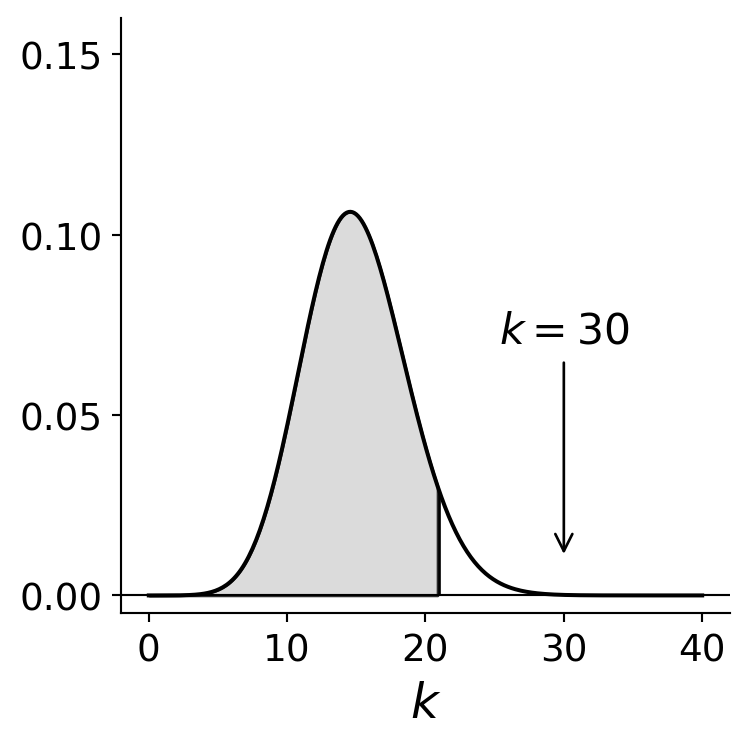

## GO Overrepresentation with the Binomial Distribution

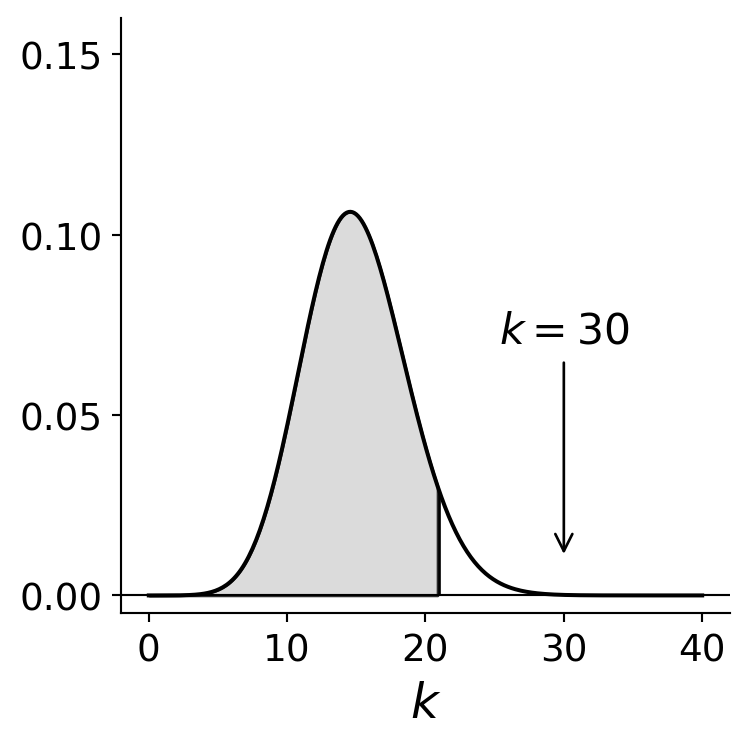

# binomial vs hypergeometric distribution

Although this approach provides a nearly correct answer for terms with many annotations in the population and large DE sets, it is actually only an approximation.

- The problem is that the binomial distribution is based on the assumption that the individual trials are independent of one another.
- While this is clearly true for coin tosses, it is not for GO overrepresentation analysis, which is rather comparable to a lotto game in which labelled balls are taken from an urn and not replaced.
- For instance, if there are 60 balls numbered 1 to 60, the chance of getting a 7 on the first draw is 1/60.
- If a 7 was drawn the first time, the chance of getting it the second time is zero.
- If another number was drawn the first time, the chance of getting a 7 the second time is 1/59, because some other ball has been removed.

# GO Overrepresentation with the hypergeometric distribution

In our microarray experiment, we imagine that the set of all 10,000 genes on the chip is represented by an urn with 10,000 balls.

## GO Overrepresentation with the Hypergeometric Distribution

- Let $m$ be the number of genes on the microarray chip.
  - $m_t$ be the number of these genes that are annotated to GO term $t$.
  - $n$ be the number of DE genes (the study set).
  - $k$ be the number of DE genes that are annotated to $t$.
- We have:
  $$P(k,n,m,m_t) = \dfrac{\binom{m_t}{k}\binom{m-m_t}{n-k}}{\binom{m}{n}}$$
- Numerator: $\binom{m_t}{k}\binom{m-m_t}{n-k}$: The number of ways to choose exactly $k$ annotated genes AND $n-k$ non-annotated genes.
- Denominator: $\binom{m}{n}$: The total number of ways to choose any $n$ genes from the population $m$.

# GO Overrepresentation with the Hypergeometric Distribution

$$p(k,n,m,m_t) = \dfrac{\binom{m_t}{k}\binom{m-m_t}{n-k}}{\binom{m}{n}}
\tag{4}$$

- Ways to choose annotated genes: There are $\binom{m_t}{k}$ ways of choosing $k$ genes annotated to $t$.
- Ways to choose non-annotated genes: There are $\binom{m-m_t}{n-k}$ ways of choosing the remaining $n-k$ genes that are not annotated to $t$.
- Combined combinations: In total, there are $\binom{m_t}{k}\binom{m-m_t}{n-k}$ ways of choosing the genes in the study set such that $k$ are annotated to $t$ and $n-k$ are not.
- Total possible outcomes: There are $\binom{m}{n}$ total ways of choosing a study set with $n$ genes from the population of $m$ genes with arbitrary annotations.
- The hypergeometric equation reflects the proportion of all possible study sets that can be chosen from the population such that exactly $k$ of the genes are annotated to $t$. If this proportion is very small, it is unlikely that such a study set will be chosen at random.

# GO Overrepresentation with the Hypergeometric Distribution

Equation 4 is known as the `hypergeometric distribution`.

- Analogously to the situation with the binomial distribution, we need to calculate the probability of observing some number $k$ or more genes annotated to $t$ in order to have a statistical test.
- In this case, the sum over the tail of the hypergeometric distribution is known as the `Fisher Exact Test`:

## GO Overrepresentation with Fisher’s exact test

- We refer to the set of genes<sup>1</sup> which are investigated in an experiment as the `population set`.
- The cardinality (count) of the population set is refered to as $m$
- In RNA-seq, the population set can be defined as all measured genes
- In microarray or other targeted experiments, we might define the population set as all genes that the microarray chip can detect.
- The outcome of the experiment is referred to as the `study set`. The cardinality of the study set is $n$.
- In the microarray or RNA-seq scenario the study set could consist of all genes that were detected to be differentially expressed.
- The count of genes in the population that are annotated to GO term $t$ is $m_t$.
- $k$ is the number of genes in the study set annotated to GO term $t$

[^3]: We use the term `gene` only for simplicity. The items annotated to the ontology terms may also be proteins or other biological entities.

## Term-for-Term

**Note**

The actual testing procedure for the most basic kind of GO analysis involves performing one statistical test for each GO term that is represented in the dataset of interest (usually this means we are performing thousands of tests)

For each tested GO term, we have:

- Null Hypothesis ($H_0$): there is no positive association between genes annotated to the term $t$ and the study set; that is, there is no overrepresentation of term $t$.
- Alternative Hypothesis ($H_1$): There is overrepresentation of the term.
- The null hypothesis corresponds to the probability of observing a test statistic that is at least as extreme as the one that was observed given that the null hypothesis is true.
- Therefore, the null hypothesis corresponding to a one-sided test is rejected if the probability of observing $n_t$ genes annotated to term $t$ in the study set by chance is less than $\alpha$
- By convention, $\alpha$ is usually set to 0.05

  This is given by:

$$P(X_t\geq n_t|H_0) = \sum_{k=n_t}^{\min(m_t,n)}
\frac{\displaystyle{m_t \choose k}\displaystyle{{m - m_t}
\choose {n - k}}}{\displaystyle{m \choose n}}.$$

## Interpretation of significant GO terms

- if $P(X_t\geq n_t|H_0) < \alpha$, the null hypothesis is rejected, and we declare the term $t$ to be in the study set.
- The biological interpretation of significant overrepresentation is usually taken to be that the term $t$ represents an important biological characteristic of the study set.

## Example

- Suppose that there is a population set of $m=18$ genes, of which $m_t=4$ genes are annotated to the term $t$.
- The outcome of an experiment conducted on all 18 genes of the population yields a set of 5 genes. This means that the study set consists of $n=5$ genes.
- Moreover, we observe that a total of $n_t=3$ genes from the genes of the study set are annotated to term $t$

## Multiple testing correction

[figure not shown]

- multiple testing problem occurs when many statistical tests are performed on the same dataset.
- Each test has its own chance of a Type I error (false positive)
- The overall probability of making at least one false positive increases as the number of tests grows.
- If m independent comparisons are performed, the family-wise error rate (FWER), is given by
  $$\bar {\alpha }=1-\left(1-\alpha _{\{{\text{per comparison}}\}}\right)^{m}$$
- The Bonferroni correction sets $\alpha _{\mathrm {\{per\ comparison\}} }=\frac{\alpha }{m}$
- We will not go into detail in this course; there are many other MTC procedures

## Ontologizer

[figure not shown]

- HOMEWORK You will process several datasets with the Ontologizer to gain intuition about GO TfT analysis.

## Gene set enrichment analysis

- Drawbacks of GO Overrepresentation Analysis (GOOA)
  - After correcting for multiple hypotheses testing, no individual gene may meet the threshold for statistical significance, because the relevant biological differences are modest relative to the noise inherent to the microarray technology.
  - The threshold for signicance is arbitrary. What about genes with p=0.051? Maybe they would become significant if we did more repetitions in our RNA-seq experiment
- Gene Set Enrichment Analysis (GSEA):
  - Do not divide genes into study (differentially expressed) and population (all genes)
  - Instead, rank genes according to degree of expression or differential expression
  - Determine whether members of a gene set *S* tend to occur toward the top (or bottom) of the list **L**
  - In this case the gene set is correlated with the phenotypic class distinction.

Subramanian A, et al. (2005) Gene set enrichment analysis: a knowledge-based approach for interpreting genome-wide expression profiles. Proc Natl Acad Sci U S A. **102**:15545-50. PMID: 16199517.

## GSEA: concepts

- GSEA considers experiments with genomewide expression profiles from samples belonging to two classes, labeled 1 or 2.
- Genes are ranked based on the correlation between their expression and the class distinction by using any suitable metric
- Concretely, class 1 can be `Annotated to GO term *t*` and class 2 `Not annotated to *t*`

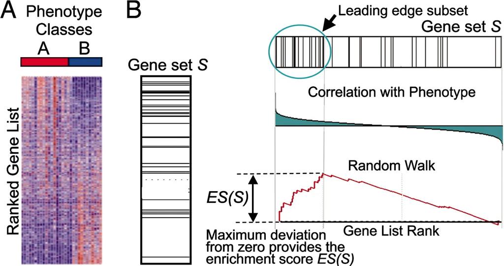

## GSEA: Enrichment Score

- The enrichment score (ES) that reflects the degree to which a set *S* is overrepresented at the extremes (top or bottom) of the entire ranked list **L**.
- The score is calculated by walking down the list L, increasing a running-sum statistic when we encounter a gene in S and decreasing it when we encounter genes not in S.
- The magnitude of the increment depends on the correlation of the gene with the phenotype.
- The enrichment score is the maximum deviation from zero encountered in the random walk; it corresponds to a weighted Kolmogorov–Smirnov-like statistic

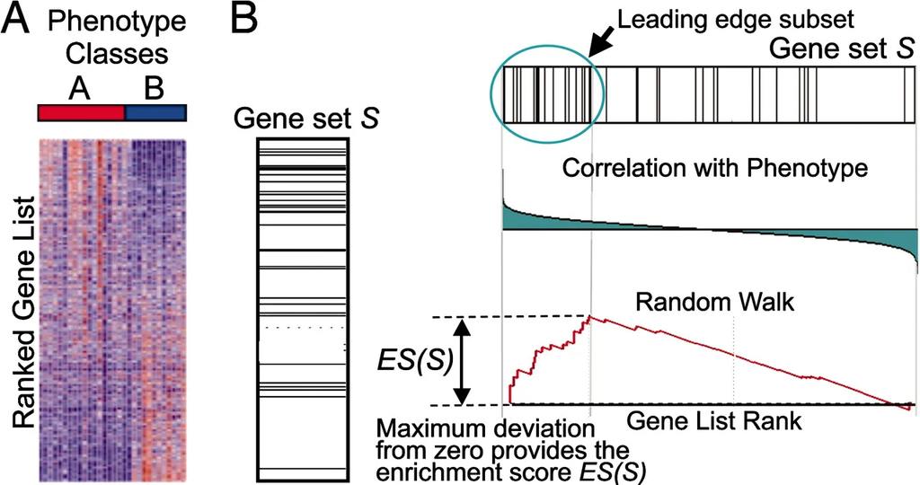

## GSEA: Enrichment score setup

- `Input`: A ranked list of *N* genes, ordered by some gene-level statistic
  - correlation with phenotype
  - differential expression
  - a t statistic
- The most differentially expressed genes are placed at the top of the list, the least differential at the bottom.

The original GSEA implementation had a type of signal to noise ratio (Difference of class means divided by sum of class standard deviations. This is essentially a variance-stabilized fold-change)

$$r_j = \frac{\mu_{j,A} - \mu_{j,B}}{\sigma_{j,A} + \sigma_{j,B}}$$

- Favors genes with a large, *consistent* (low-variance) difference between groups over genes with a large but noisy difference.
- Similar in intent to a t-test, which most implementations use now

## GSEA: Running Sum

The running-sum construction - Walk down the ranked list from position $j=1,\ldots,N$ - At each step, maintain two running sums:

$$P_{hit}(S,i) = \sum_{\substack{j \le i \\ g_j \in S}} \dfrac{|r_j|^p}{N_R}
\quad\quad N_R = \sum_{g_j\in S}|r_j|^p
\tag{6}$$

- The `hit` term of Equation 6 increases whenever it encounters a gene that belongs to $S$, weighted by the magnitude of its ranking statistic $r_j$

and

$$P_{miss}(S,i) = \sum_{\substack{j \le i \\ g_j \notin S}}\dfrac{1}{N-N_H}$$

- The `miss` term increases whenever it encounters a gene not in *S*, with a uniform step size.
- Both are normalized so each is a proper empirical CDF: they start at 0, and $P_{hit}(S,N) = P_{miss}(S,N) = 1$.

## GSEA: Running Sum

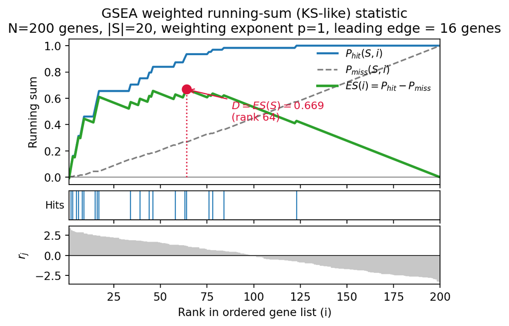

# The enrichment score

The enrichment score is the maximum deviation between these two running sums as you sweep across the whole list:

$$ES(S) = \max_i [P_{hit}(S,i) - P_{miss}(S,i)]
\tag{7}$$

- If we are intested in negative deviations (bottom of the list), then we would track the signed max (whichever of the maximum positive or maximum negative deviation is larger in absolute value).

## Kolmogorov–Smirnov

- HOMEWORK We will review the Kolmogorov–Smirnov (KS) test in the homework.
- GSEA is “KS-like” but not exactly a KS-test
- The classical two-sample KS test statistic is

$$D = \sup_x |CDF_1(x) - CDF_2(x)|
\tag{8}$$

- The is, the KS statistic is the largest vertical gap between two empirical cumulative distribution functions.
- GSEA is also the largest gap between two step functions, but there are three key differences
  1. GSEA takes weighted (not uniform) steps. The hit function’s step size at gene $j$ is proportional to $∣𝑟_j|^p$ (genes that are more correlated with the phenotype contribute larger jumps when they appear.)
  2. Signed max (GSEA), not absolute max (KS).
  3. Discrete, rank-based domain. The distribution being compared isn’t over a continuous variable (as with KS), it’s over discrete positions in a fixed permutation (the gene rank order), so $P_{hit}$ and $P_{miss}$ are step functions over ${1,\ldots, N}$ rather than continuous functions over $\mathbb{R}$

## Estimation of Significance Level of ES

- The calculation of the p-value in the KS test is .is computed from a known asymptotic distribution (the Kolmogorov distribution), either via an exact formula for small n or asymptotically for large n.
- GSEA has no such closed-form null
- In GSEA, the p-value is estimated empirically using permutations
- permuting phenotype labels changes the ranked gene list itself
- If the actual GSEA statistic is higher than all but 2 of 10,000 permutations, then the p value is calculated as
  $$p=\frac{b+1}{m+1} = \frac{2+1}{10000+1} \approx 3\times 10^{-4}$$
- Specifically, we permute the phenotype labels and recompute the ES of the gene set for the permuted data, which generates a null distribution for the ES.
- The empirical, nominal P value of the observed ES is then calculated relative to this null distribution.

## Adjustment for Multiple Hypothesis Testing

- The adjustment fo multiple testing is essentially the same as with GO Overrepresentation Analysis
- Skipping some details in the original publication

## GSEA: Examples

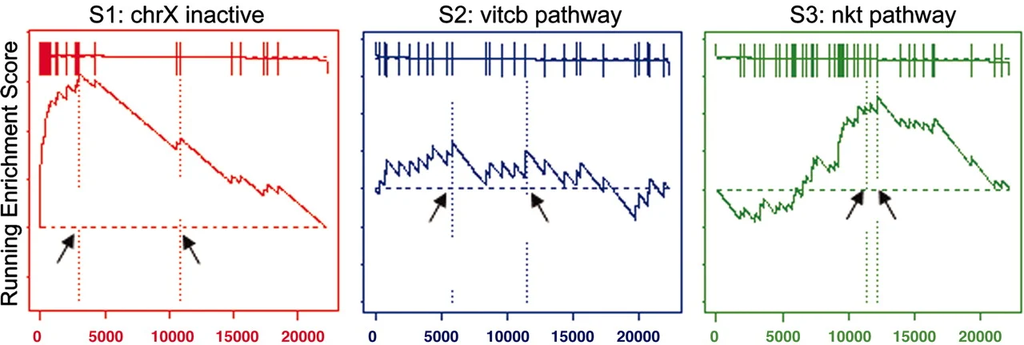

- S1 is significantly enriched and scores highly
- S2 is randomly distributed and scores poorly
- S3 is not enriched at the top of the list but is nonrandom, so it scores well (but somewhat difficult to interpret biologically)

Sources:

- Subramanian A, et al. (2005) Gene set enrichment analysis: a knowledge-based approach for interpreting genome-wide expression profiles. Proc Natl Acad Sci U S A. **102**:15545-50 PMID: 16199517.
- Mootha VK, et al. (2003) PGC-1alpha-responsive genes involved in oxidative phosphorylation are coordinately downregulated in human diabetes. Nat Genet. **34**:267-73. PMID:12808457.

## Gene Ontology Causal Activity Modeling (GO-CAM)

**GO-CAM**:

- GO-CAM, a structured framework for linking multiple GO annotations into an integrated model of a biological system.
- The development of the GO has always been tightly coupled to its use in describing the functions of genes across a wide variety of organisms.
- However, biology is better understood as a collection of coupled pathways rather than a set of individual annotations

## GO: Traditional Annotation Modeling

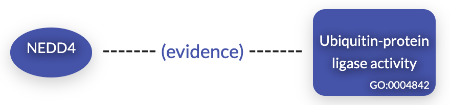

- A standard GO annotation is a gene product associated to a GO term, using an evidence code and a supporting reference (a primary research article, for example).
- These are the annotations we were examining in the previous sections
- each GO annotation is necessarily a partial functional description, and there is no representation of how different annotations for the same gene fit together into a more complete description.

Image: https://geneontology.org/docs/gocam-overview/

## GO-CAM models

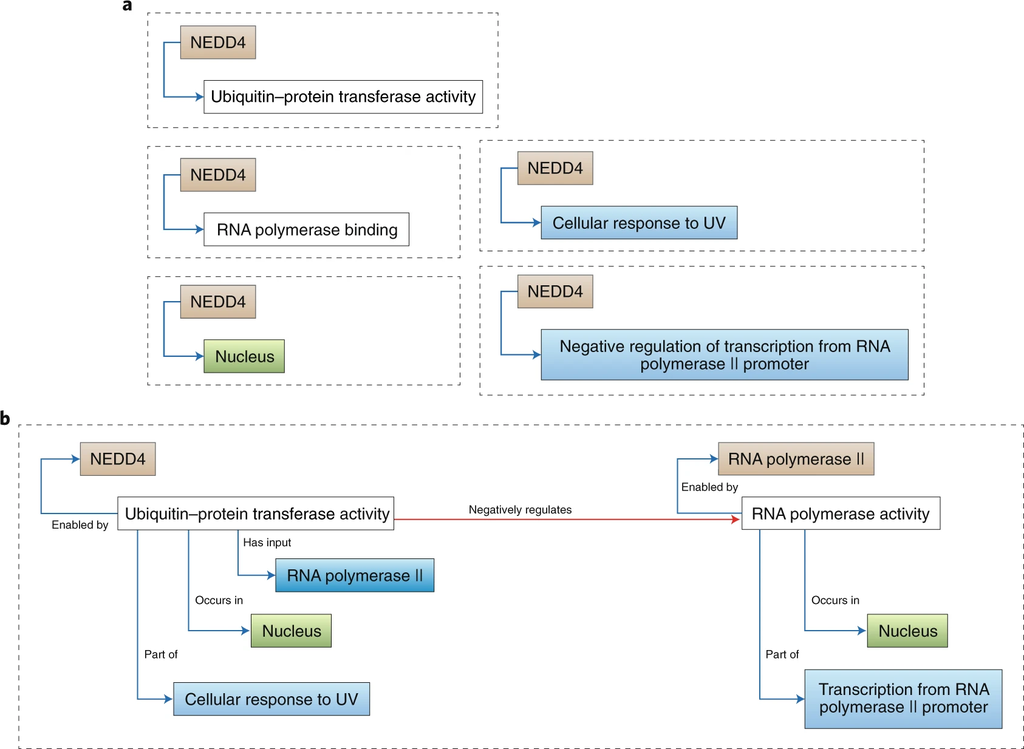

A GO-CAM model is a combination of standard GO annotations to produce a network of annotations (“model”) that is a more complete model of biological function than the separate annotations. - **a)**: set of disconnected GO annotations - **b)**: GO-CAM model links together GO annotations into a structured model of NEDD4 functions

## Specification of the GO-CAM model

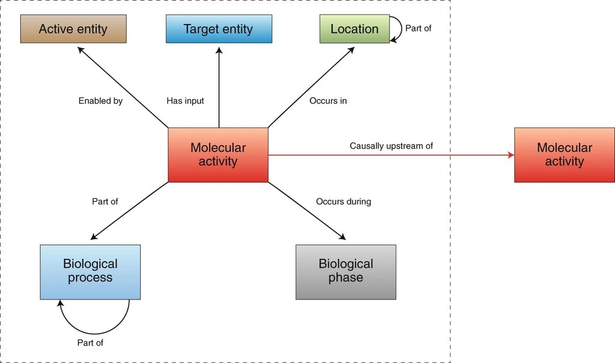

- a **molecular activity** (GO molecular function annotation) of a gene product occurs
- in a **location** (GO cellular component annotation)
- is part of a larger **biological program** (GO biological process annotation).
- In GO-CAM, relations to terms from other ontologies can provide additional specificity:
  - for location, a cellular component can be part of a specified cell type,
  - which in turn can be part of a specified anatomical structure;
  - an activity can occur during a specified temporal period (biological phase)

## GO-CAMs leverage other ontologies to specify biological activities

- The ontologies used to specificy entities shown in the above Figure include

| GO-CAM element | Ontology or identifier source(s) | Example |
| --- | --- | --- |
| Molecular activity | GO molecular function | ubiquitin-protein transferase activity (GO:0004842) |
| Biological process | GO biological process | cellular response to UV (GO:0034644) |
| Location | GO cellular component | nucleus (GO:0005634) |
|  | Cell Type Ontology (CL) | retinal cell (CL:0009004) |
|  | anatomy ontologies, e.g. UBERON, *C. elegans* gross anatomy, EMAPA | eye (UBERON:0000970) |
| Active entity | Gene, protein, RNA or complex identifier from a standard source, e.g. HGNC for a human gene | NEDD4 (HGNC:7727) |
| Target entity | Same as active entity, or chemical from ChEBI | MAP2K1 (HGNC:6840) |
| Biological phase | GO biological phase (GO:0044848) | mitotic G1 phase (GO:0000080) |
|  | Developmental phase ontology, e.g. Mouse Developmental Stage | Theiler stage 02 (MmusDv:0000005) |
| Relations | Relations Ontology | occurs in (BFO:0000066) |

- For instance, to browse the UBERON ontology, use the [OLS site](https://www.ebi.ac.uk/ols4/ontologies/uberon)

## GO-CAM browser

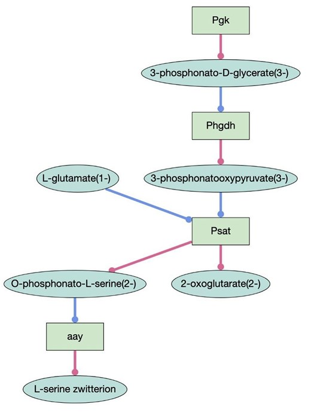

[GOCAM Browser](https://go-cam-browser.geneontology.org/)

Thomas PD, et al. (2019) [Gene Ontology Causal Activity Modeling (GO-CAM) moves beyond GO annotations to structured descriptions of biological functions and systems. *Nat Genet* **51**:1429-1433](https://pubmed.ncbi.nlm.nih.gov/31548717/)

## PAN-GO

- Another fascinating resource is PAN-GO
- explicit evolutionary modelling was applied to all human protein-coding genes
- into models that reconstruct the gain and loss of functional characteristics over evolutionary time
- This allowed additional GO annotations to be inferred, with the resulting set of 68,667 integrated gene functions cover approximately 82% of human protein-coding genes

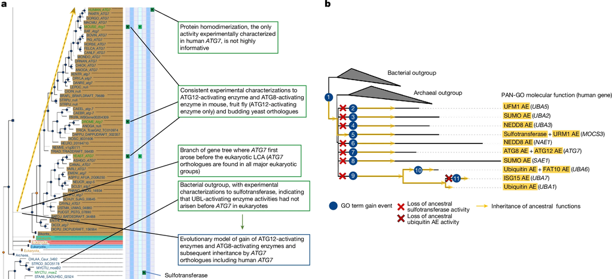

Feuermann M, et al. (2025) [A compendium of human gene functions derived from evolutionary modelling. *Nature* **640**:146-154](https://pubmed.ncbi.nlm.nih.gov/40011791/)

## Conclusion

- A major use case for bioontologies such as GO that are used to annotate biological domains (genes and gene products) is to visualize terms (biological concepts) that are overrepresented in experimental results
- We have examined two major algorithmic approaches:
  - GO Overrepresentation Analysis (Fisher Exact Test)
  - Gene-set Enrichment Analysis
- Both approaches typically require multiple testing correction because they perform hundreds or even thousands of individual tests
- New approaches such as GOCAM and PAN-GO are making GO modelling more sophisticated and providing more comprehensive functional annotations
- A foundation for understanding biology and developing bioinformatics algorithms and analysis pipelines.

## Sources

- Gene Ontology Consortium (2026) [The Gene Ontology knowledgebase in 2026. *Nucleic Acids Res* **54**:D1779-D1792](https://pubmed.ncbi.nlm.nih.gov/41413728/).
- Bauer S, et al. (2008) Ontologizer 2.0–a multifunctional tool for GO term enrichment analysis and data exploration. *Bioinformatics* **24**:1650-1](https://pubmed.ncbi.nlm.nih.gov/18511468/)
- Subramanian A, et al. (2005) Gene set enrichment analysis: a knowledge-based approach for interpreting genome-wide expression profiles. Proc Natl Acad Sci U S A. **102**:15545-50 PMID: 16199517.
- Mootha VK, et al. (2003) PGC-1alpha-responsive genes involved in oxidative phosphorylation are coordinately downregulated in human diabetes. Nat Genet. **34**:267-73. PMID:12808457.
- Thomas PD, et al. (2019) [Gene Ontology Causal Activity Modeling (GO-CAM) moves beyond GO annotations to structured descriptions of biological functions and systems. *Nat Genet* **51**:1429-1433](https://pubmed.ncbi.nlm.nih.gov/31548717/)